# R Notebook

# PART 5 : Cross Validation

```r
library(readr)
AmesTrain8 <- read_csv("~/Desktop/College/Junior/Stor 455/AmesTrain8.csv")
AmesTest8 <- read_csv("~/Desktop/College/Junior/Stor 455/AmesTest8.csv")
basic_model <- lm(Price ~ LotFrontage + LotArea + Quality + Condition +
    YearBuilt + YearRemodel + BasementFinSF + BasementSF + FirstSF +
    SecondSF + BasementHBath + Bedroom + TotalRooms + Fireplaces +
    GarageSF + OpenPorchSF, data = AmesTrain8)
```

```r
summary(basic_model)
```

```
Call:
lm(formula = Price ~ LotFrontage + LotArea + Quality + Condition +
    YearBuilt + YearRemodel + BasementFinSF + BasementSF + FirstSF +
    SecondSF + BasementHBath + Bedroom + TotalRooms + Fireplaces +
    GarageSF + OpenPorchSF, data = AmesTrain8)

Residuals:
     Min       1Q   Median       3Q      Max
-127.153  -16.417   -0.575   13.414  180.877

Coefficients:
                Estimate Std. Error t value Pr(>|t|)
(Intercept)   -1.324e+03  1.508e+02  -8.780  < 2e-16 ***
LotFrontage    1.254e-01  3.540e-02   3.542 0.000429 ***
LotArea        4.686e-04  1.244e-04   3.768 0.000182 ***
Quality        1.468e+01  1.467e+00  10.008  < 2e-16 ***
Condition      4.537e+00  1.338e+00   3.392 0.000742 ***
YearBuilt      4.163e-01  6.537e-02   6.368 3.88e-10 ***
YearRemodel    2.133e-01  8.400e-02   2.539 0.011364 *
BasementFinSF  2.397e-02  3.266e-03   7.340 7.23e-13 ***
BasementSF     1.971e-02  5.015e-03   3.930 9.52e-05 ***
FirstSF        5.511e-02  7.172e-03   7.684 6.55e-14 ***
SecondSF       4.908e-02  5.252e-03   9.346  < 2e-16 ***
BasementHBath -6.989e+00  4.913e+00  -1.423 0.155409
Bedroom       -1.431e+01  2.201e+00  -6.501 1.72e-10 ***
TotalRooms     6.288e+00  1.522e+00   4.132 4.12e-05 ***
Fireplaces     6.077e+00  2.244e+00   2.708 0.006965 **
GarageSF       3.938e-02  7.232e-03   5.446 7.61e-08 ***
OpenPorchSF    3.701e-02  2.156e-02   1.716 0.086614 .
---
Signif. codes:  0 ‘***’ 0.001 ‘**’ 0.01 ‘*’ 0.05 ‘.’ 0.1 ‘ ’ 1

Residual standard error: 28.84 on 583 degrees of freedom
Multiple R-squared:  0.8594,    Adjusted R-squared:  0.8555
F-statistic: 222.7 on 16 and 583 DF,  p-value: < 2.2e-16
```

```r
fitPrice = predict(basic_model, newdata=AmesTest8)
holdout_resids = AmesTest8$Price - fitPrice
mean(holdout_resids)
```

```
[1] 0.228936
```

```r
sd(holdout_resids)
```

```
[1] 24.87142
```

The mean of the holdout residuals are quite small and close to zero, which is what we expect from a model that predicts the price fairly well. The standard deviation of about $25,000 is also reasonable given the price ranges of the houses.

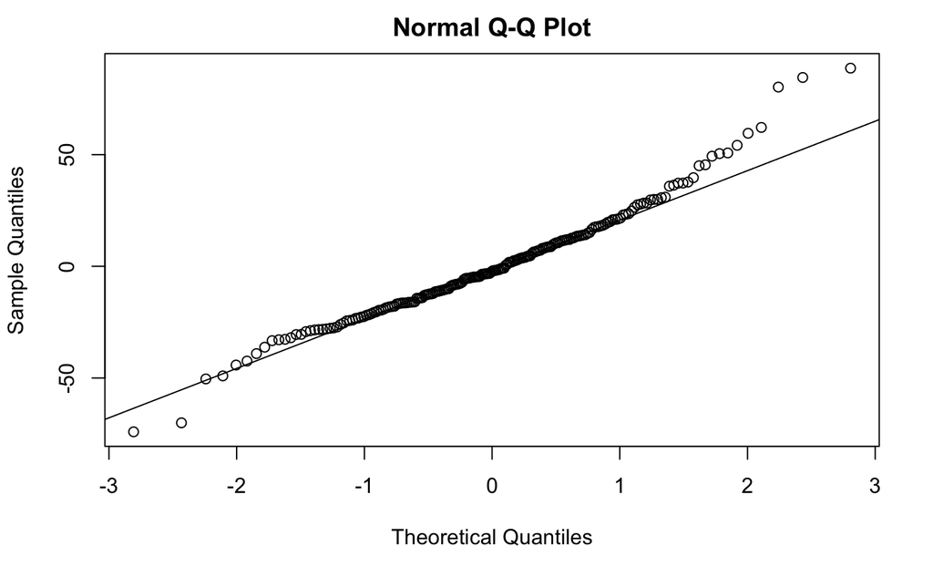

```r
qqnorm(holdout_resids)
qqline(holdout_resids)
```

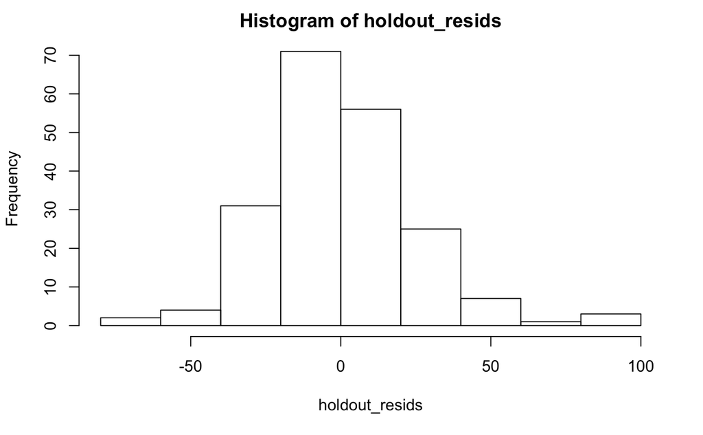

```r
hist(holdout_resids)
```

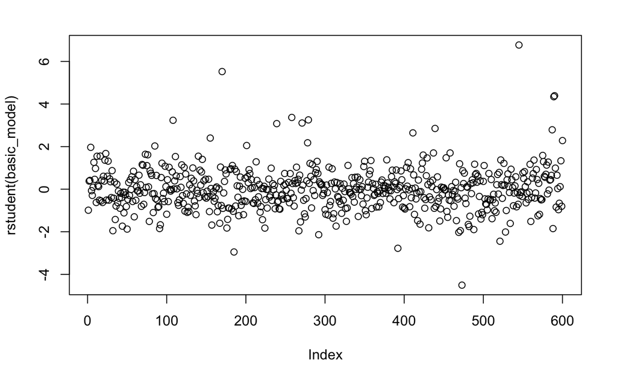

```r
plot(rstudent(basic_model))
```

```r
head(sort(rstudent(basic_model),decreasing=TRUE),n=10)
```

```
     545      170      590      589      258      279      108      271      239      439
6.772511 5.525354 4.390197 4.343721 3.369223 3.254552 3.237170 3.108114 3.079827 2.852592
```

```r
crosscor=cor(AmesTest8$Price, fitPrice)
crosscor
```

```
[1] 0.9329168
```

```r
0.8594 - crosscor^2
```

```
[1] -0.01093376
```

The shrinkage is negative which is not terrible because a large shrinkage is bad. Our model is fitting the test data better than the training data, therefore we do not see a need to change this model at this time.

# PART 6 : Find a “fancy” model

```r
trainData <- AmesTrain8
trainData[,"age1"]=2018-trainData$YearBuilt
trainData[,"age2"]=2018-trainData$YearRemodel
trainData = trainData[-c(170,545),]
oldFancyModel=lm(log(Price)~I(age1+age2)+I(LotFrontage+LotArea+GarageSF+LotArea*GarageSF)+I(Quality+Condition+Quality*Condition)+I(0.5*BasementFinSF+0.5*BasementSF+FirstSF+SecondSF+Bedroom+(TotalRooms^2))+I(sqrt(Fireplaces)),data=trainData)
summary(oldFancyModel)
```

```
Call:
lm(formula = log(Price) ~ I(age1 + age2) + I(LotFrontage + LotArea +
    GarageSF + LotArea * GarageSF) + I(Quality + Condition +
    Quality * Condition) + I(0.5 * BasementFinSF + 0.5 * BasementSF +
    FirstSF + SecondSF + Bedroom + (TotalRooms^2)) + I(sqrt(Fireplaces)),
    data = trainData)

Residuals:
     Min       1Q   Median       3Q      Max
-0.82853 -0.06621  0.00090  0.08167  0.40176

Coefficients:
                                                                                            Estimate
(Intercept)                                                                                4.344e+00
I(age1 + age2)                                                                            -3.270e-03
I(LotFrontage + LotArea + GarageSF + LotArea * GarageSF)                                   6.327e-09
I(Quality + Condition + Quality * Condition)                                               7.851e-03
I(0.5 * BasementFinSF + 0.5 * BasementSF + FirstSF + SecondSF + Bedroom + (TotalRooms^2))  2.668e-04
I(sqrt(Fireplaces))                                                                        7.379e-02
                                                                                          Std. Error t value
(Intercept)                                                                                3.610e-02 120.347
I(age1 + age2)                                                                             1.378e-04 -23.738
I(LotFrontage + LotArea + GarageSF + LotArea * GarageSF)                                   1.090e-09   5.803
I(Quality + Condition + Quality * Condition)                                               5.887e-04  13.336
I(0.5 * BasementFinSF + 0.5 * BasementSF + FirstSF + SecondSF + Bedroom + (TotalRooms^2))  1.080e-05  24.713
I(sqrt(Fireplaces))                                                                        1.199e-02   6.154
                                                                                          Pr(>|t|)
(Intercept)                                                                                < 2e-16 ***
I(age1 + age2)                                                                             < 2e-16 ***
I(LotFrontage + LotArea + GarageSF + LotArea * GarageSF)                                  1.06e-08 ***
I(Quality + Condition + Quality * Condition)                                               < 2e-16 ***
I(0.5 * BasementFinSF + 0.5 * BasementSF + FirstSF + SecondSF + Bedroom + (TotalRooms^2))  < 2e-16 ***
I(sqrt(Fireplaces))                                                                       1.39e-09 ***
---
Signif. codes:  0 ‘***’ 0.001 ‘**’ 0.01 ‘*’ 0.05 ‘.’ 0.1 ‘ ’ 1

Residual standard error: 0.1377 on 592 degrees of freedom
Multiple R-squared:   0.87, Adjusted R-squared:  0.8689
F-statistic: 792.7 on 5 and 592 DF,  p-value: < 2.2e-16
```

This code loads in our old fancy model from the previous assignment.

```r
nums = unlist(lapply(AmesTrain8, is.character))
cat <- AmesTrain8[, nums]
cat <- as.data.frame(apply(cat, MARGIN = c(1,2), FUN = factor))
catPredictors = cbind(log(AmesTrain8$Price), cat)
names(catPredictors)[1] <- "Price"
```

This code retrieves only the categorical variables from the dataset.

```r
full = lm(Price ~ . , data = catPredictors)
MSE = (summary(full)$sigma)^2
step(full, scale = MSE, trace=0)
```

```
Call:
lm(formula = Price ~ LotConfig + HouseStyle + ExteriorQ + BasementHt +
    BasementC + BasementFin + Heating + HeatingQC + KitchenQ +
    GarageType + GarageQ + GarageC, data = catPredictors)

Coefficients:
      (Intercept)   LotConfigCulDSac       LotConfigFR2       LotConfigFR3    LotConfigInside
          6.41915            0.07737           -0.14474            0.12561           -0.02694
 HouseStyle1.5Unf   HouseStyle1Story   HouseStyle2.5Fin   HouseStyle2.5Unf   HouseStyle2Story
         -0.30688           -0.14552            0.07344            0.04039           -0.06897
 HouseStyleSFoyer     HouseStyleSLvl        ExteriorQFa        ExteriorQGd        ExteriorQTA
         -0.22959           -0.13466           -0.35935           -0.12249           -0.19747
     BasementHtFa       BasementHtGd     BasementHtNone       BasementHtTA        BasementCFa
         -0.49677           -0.25977           -0.80462           -0.38008           -0.51365
      BasementCGd      BasementCNone        BasementCPo        BasementCTA     BasementFinBLQ
         -0.29207                 NA           -0.46279           -0.32979            0.04427
   BasementFinGLQ     BasementFinLwQ    BasementFinNone     BasementFinRec     BasementFinUnf
          0.02524            0.14182                 NA           -0.01315           -0.03056
      HeatingGasW        HeatingGrav        HeatingOthW        HeatingWall        HeatingQCFa
          0.06998           -0.47703           -0.02529           -0.18422           -0.01464
      HeatingQCGd        HeatingQCTA         KitchenQFa         KitchenQGd         KitchenQPo
         -0.03407           -0.10930           -0.32837           -0.17169           -0.07962
       KitchenQTA   GarageTypeAttchd  GarageTypeBasment  GarageTypeBuiltIn   GarageTypeDetchd
         -0.26469           -0.03206           -0.32224           -0.01134           -0.21341
   GarageTypeNone          GarageQFa          GarageQGd        GarageQNone          GarageQPo
         -0.26522           -0.62905           -0.24770                 NA           -0.43314
        GarageQTA          GarageCFa          GarageCGd        GarageCNone          GarageCPo
         -0.45417            0.24287            0.69826                 NA            0.66031
        GarageCTA
          0.43674
```

```r
none = lm(Price~1, data=catPredictors)
step(none, scope=list(upper=full), scale=MSE, direction="forward", trace=0)
```

```
Call:
lm(formula = Price ~ BasementHt + KitchenQ + GarageType + ExteriorQ +
    GarageC + LotConfig + HouseStyle + Foundation + HeatingQC +
    BasementC + BasementFin + Heating + GarageQ, data = catPredictors)

Coefficients:
      (Intercept)       BasementHtFa       BasementHtGd     BasementHtNone       BasementHtTA
         6.341083          -0.484117          -0.260415          -0.897184          -0.369387
       KitchenQFa         KitchenQGd         KitchenQPo         KitchenQTA   GarageTypeAttchd
        -0.339777          -0.170865          -0.069947          -0.266102          -0.039203
GarageTypeBasment  GarageTypeBuiltIn   GarageTypeDetchd     GarageTypeNone        ExteriorQFa
        -0.330500          -0.018622          -0.213148          -0.258319          -0.358231
      ExteriorQGd        ExteriorQTA          GarageCFa          GarageCGd        GarageCNone
        -0.123637          -0.196917           0.252218           0.711985                 NA
        GarageCPo          GarageCTA   LotConfigCulDSac       LotConfigFR2       LotConfigFR3
         0.683204           0.452025           0.079891          -0.142545           0.141549
  LotConfigInside   HouseStyle1.5Unf   HouseStyle1Story   HouseStyle2.5Fin   HouseStyle2.5Unf
        -0.023793          -0.302985          -0.158976           0.097006           0.034921
 HouseStyle2Story   HouseStyleSFoyer     HouseStyleSLvl   FoundationCBlock    FoundationPConc
        -0.081868          -0.242285          -0.146502           0.064787           0.086284
   FoundationSlab    FoundationStone     FoundationWood        HeatingQCFa        HeatingQCGd
         0.221869           0.047781           0.224713          -0.001648          -0.024515
      HeatingQCTA        BasementCFa        BasementCGd      BasementCNone        BasementCPo
        -0.100881          -0.494213          -0.286356                 NA          -0.400003
      BasementCTA     BasementFinBLQ     BasementFinGLQ     BasementFinLwQ    BasementFinNone
        -0.318909           0.042564           0.021157           0.133044                 NA
   BasementFinRec     BasementFinUnf        HeatingGasW        HeatingGrav        HeatingOthW
        -0.010521          -0.033463           0.096784          -0.420990           0.022140
      HeatingWall          GarageQFa          GarageQGd        GarageQNone          GarageQPo
        -0.240912          -0.599400          -0.256037                 NA          -0.435581
        GarageQTA
        -0.465991
```

```r
step(none, scope=list(upper=full), scale=MSE, trace=0)
```

```
Call:
lm(formula = Price ~ BasementHt + KitchenQ + GarageType + ExteriorQ +
    GarageC + LotConfig + HouseStyle + HeatingQC + BasementC +
    BasementFin + Heating + GarageQ, data = catPredictors)

Coefficients:
      (Intercept)       BasementHtFa       BasementHtGd     BasementHtNone       BasementHtTA
          6.41915           -0.49677           -0.25977           -0.80462           -0.38008
       KitchenQFa         KitchenQGd         KitchenQPo         KitchenQTA   GarageTypeAttchd
         -0.32837           -0.17169           -0.07962           -0.26469           -0.03206
GarageTypeBasment  GarageTypeBuiltIn   GarageTypeDetchd     GarageTypeNone        ExteriorQFa
         -0.32224           -0.01134           -0.21341           -0.26522           -0.35935
      ExteriorQGd        ExteriorQTA          GarageCFa          GarageCGd        GarageCNone
         -0.12249           -0.19747            0.24287            0.69826                 NA
        GarageCPo          GarageCTA   LotConfigCulDSac       LotConfigFR2       LotConfigFR3
          0.66031            0.43674            0.07737           -0.14474            0.12561
  LotConfigInside   HouseStyle1.5Unf   HouseStyle1Story   HouseStyle2.5Fin   HouseStyle2.5Unf
         -0.02694           -0.30688           -0.14552            0.07344            0.04039
 HouseStyle2Story   HouseStyleSFoyer     HouseStyleSLvl        HeatingQCFa        HeatingQCGd
         -0.06897           -0.22959           -0.13466           -0.01464           -0.03407
      HeatingQCTA        BasementCFa        BasementCGd      BasementCNone        BasementCPo
         -0.10930           -0.51365           -0.29207                 NA           -0.46279
      BasementCTA     BasementFinBLQ     BasementFinGLQ     BasementFinLwQ    BasementFinNone
         -0.32979            0.04427            0.02524            0.14182                 NA
   BasementFinRec     BasementFinUnf        HeatingGasW        HeatingGrav        HeatingOthW
         -0.01315           -0.03056            0.06998           -0.47703           -0.02529
      HeatingWall          GarageQFa          GarageQGd        GarageQNone          GarageQPo
         -0.18422           -0.62905           -0.24770                 NA           -0.43314
        GarageQTA
         -0.45417
```

```r
newFancyModel=lm(log(Price)~I(age1+age2)+I(LotFrontage+LotArea+GarageSF+LotArea*GarageSF)+I(Quality+Condition+Quality*Condition)+I(0.5*BasementFinSF+0.5*BasementSF+FirstSF+SecondSF+Bedroom+(TotalRooms^2))+I(sqrt(Fireplaces))+
    factor(LotConfig) + factor(HouseStyle) + factor(ExteriorQ) + factor(BasementHt) + factor(BasementC) +
    factor(BasementFin) + factor(Heating) +  factor(HeatingQC) +  factor(KitchenQ) + factor(GarageType) +
    factor(GarageQ) + factor(GarageC), data=trainData)
summary(newFancyModel)
```

```
Call:
lm(formula = log(Price) ~ I(age1 + age2) + I(LotFrontage + LotArea +
    GarageSF + LotArea * GarageSF) + I(Quality + Condition +
    Quality * Condition) + I(0.5 * BasementFinSF + 0.5 * BasementSF +
    FirstSF + SecondSF + Bedroom + (TotalRooms^2)) + I(sqrt(Fireplaces)) +
    factor(LotConfig) + factor(HouseStyle) + factor(ExteriorQ) +
    factor(BasementHt) + factor(BasementC) + factor(BasementFin) +
    factor(Heating) + factor(HeatingQC) + factor(KitchenQ) +
    factor(GarageType) + factor(GarageQ) + factor(GarageC), data = trainData)

Residuals:
     Min       1Q   Median       3Q      Max
-0.72613 -0.05784  0.00198  0.06862  0.45761

Coefficients: (4 not defined because of singularities)
                                                                                            Estimate
(Intercept)                                                                                4.886e+00
I(age1 + age2)                                                                            -1.894e-03
I(LotFrontage + LotArea + GarageSF + LotArea * GarageSF)                                   4.206e-09
I(Quality + Condition + Quality * Condition)                                               6.161e-03
I(0.5 * BasementFinSF + 0.5 * BasementSF + FirstSF + SecondSF + Bedroom + (TotalRooms^2))  2.530e-04
I(sqrt(Fireplaces))                                                                        6.248e-02
factor(LotConfig)CulDSac                                                                  -1.072e-02
factor(LotConfig)FR2                                                                      -7.096e-02
factor(LotConfig)FR3                                                                       4.176e-02
factor(LotConfig)Inside                                                                   -1.371e-02
factor(HouseStyle)1.5Unf                                                                   4.066e-02
factor(HouseStyle)1Story                                                                  -3.153e-02
factor(HouseStyle)2.5Fin                                                                  -1.872e-01
factor(HouseStyle)2.5Unf                                                                  -1.620e-01
factor(HouseStyle)2Story                                                                  -2.988e-02
factor(HouseStyle)SFoyer                                                                  -4.042e-02
factor(HouseStyle)SLvl                                                                    -1.074e-03
factor(ExteriorQ)Fa                                                                       -1.268e-01
factor(ExteriorQ)Gd                                                                       -2.345e-02
factor(ExteriorQ)TA                                                                       -5.325e-02
factor(BasementHt)Fa                                                                      -1.544e-01
factor(BasementHt)Gd                                                                      -1.016e-01
factor(BasementHt)None                                                                    -1.939e-01
factor(BasementHt)TA                                                                      -1.586e-01
```

[output cut: 152 more lines]

```
factor(GarageQ)Gd                                                                         0.699491
factor(GarageQ)None                                                                             NA
factor(GarageQ)Po                                                                         0.260531
factor(GarageQ)TA                                                                         0.809885
factor(GarageC)Fa                                                                         0.490282
factor(GarageC)Gd                                                                         0.328683
factor(GarageC)None                                                                             NA
factor(GarageC)Po                                                                         0.466017
factor(GarageC)TA                                                                         0.997423
---
Signif. codes:  0 ‘***’ 0.001 ‘**’ 0.01 ‘*’ 0.05 ‘.’ 0.1 ‘ ’ 1

Residual standard error: 0.1241 on 541 degrees of freedom
Multiple R-squared:  0.9036,    Adjusted R-squared:  0.8936
F-statistic: 90.51 on 56 and 541 DF,  p-value: < 2.2e-16
```

The summary of the new fancy model shows that it has a pretty high R-squared value of 0.9036, meaning that the model explains about 90.36% of the variability in house prices. It is also statistically significant and effective according to the F-statistic.

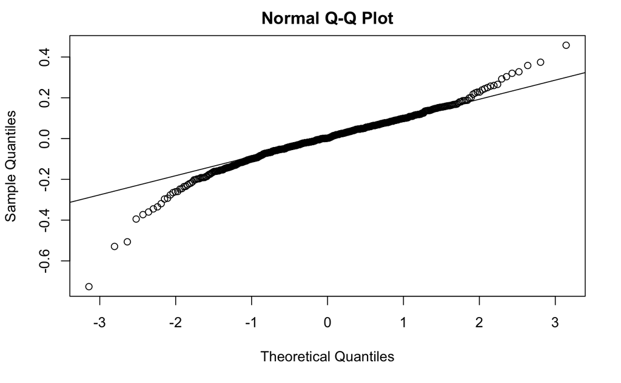

```r
qqnorm(newFancyModel$residuals)
qqline(newFancyModel$residuals)
```

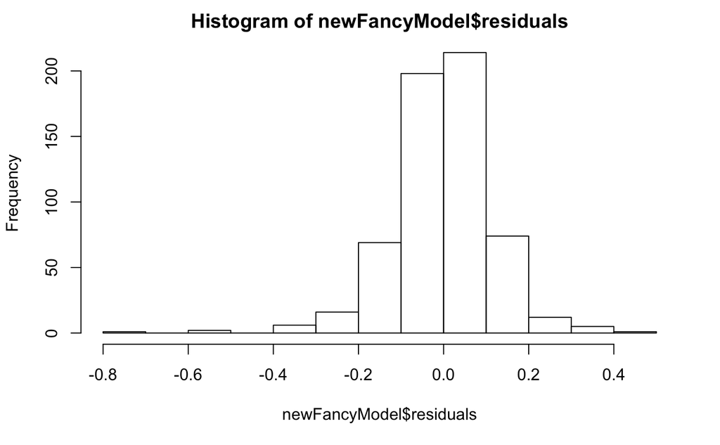

```r
hist(newFancyModel$residuals)
```

Our new fancy model seems to produce residuals that are distributed normally in the center but very poorly near the extremes.

# PART 7 : Cross-validation for “fancy” model

```r
testData = AmesTest8
testData[,"age1"]=2018-testData$YearBuilt
testData[,"age2"]=2018-testData$YearRemodel
testData$BasementHt[testData$BasementHt == "0"] = "None"
testData$BasementFin[testData$BasementFin == "0"] = "None"
testData$BasementC[testData$BasementC == "0"] = "None"
```

We had to fix up the data a little bit, converting “0” values to the equivalent value of “None”

```r
fitNewPrice = predict(newFancyModel, newdata=testData)
```

```
prediction from a rank-deficient fit may be misleading
```

```r
newHoldout_resids = testData$Price - exp(fitNewPrice)
mean(newHoldout_resids)
```

```
[1] 2.922071
```

```r
sd(newHoldout_resids)
```

```
[1] 22.42529
```

```r
crosscor=cor(testData$Price, exp(fitNewPrice))
crosscor
```

```
[1] 0.9463632
```

```r
0.9036 - crosscor^2
```

```
[1] 0.007996614
```

We now get a really small positive shrinkage of 0.007996614 which is more of what we expect, where the model for the training data explains more variability in the training data than it does for the testing data. But being so small, it also means that our model is doing quite a good job of predicting prices for houses in both datasets. The mean for the residuals has gone up, but the standard deviation has gone down when compared to our basic model, which means the spread of our residuals is smaller which is good. R does give us a warning “prediction from a rank-deficient fit may be misleading”, so we might have some multicollinearity issues.

# PART 8 : Final model

```r
finalModel=lm(log(Price)~I(age1+age2)+I(LotFrontage+LotArea+GarageSF+LotArea*GarageSF)+I(Quality+Condition+Quality*Condition)+I(0.5*BasementFinSF+0.5*BasementSF+FirstSF+SecondSF+Bedroom+(TotalRooms^2))+I(sqrt(Fireplaces))+
    factor(LotConfig) + factor(HouseStyle) + factor(ExteriorQ) + factor(BasementFin) + factor(Heating) +  factor(HeatingQC) +  factor(GarageType) , data=trainData)
summary(finalModel)
```

```
Call:
lm(formula = log(Price) ~ I(age1 + age2) + I(LotFrontage + LotArea +
    GarageSF + LotArea * GarageSF) + I(Quality + Condition +
    Quality * Condition) + I(0.5 * BasementFinSF + 0.5 * BasementSF +
    FirstSF + SecondSF + Bedroom + (TotalRooms^2)) + I(sqrt(Fireplaces)) +
    factor(LotConfig) + factor(HouseStyle) + factor(ExteriorQ) +
    factor(BasementFin) + factor(Heating) + factor(HeatingQC) +
    factor(GarageType), data = trainData)

Residuals:
     Min       1Q   Median       3Q      Max
-0.76502 -0.05801  0.00375  0.07622  0.40531

Coefficients:
                                                                                            Estimate
(Intercept)                                                                                4.630e+00
I(age1 + age2)                                                                            -2.582e-03
I(LotFrontage + LotArea + GarageSF + LotArea * GarageSF)                                   4.516e-09
I(Quality + Condition + Quality * Condition)                                               6.778e-03
I(0.5 * BasementFinSF + 0.5 * BasementSF + FirstSF + SecondSF + Bedroom + (TotalRooms^2))  2.682e-04
I(sqrt(Fireplaces))                                                                        6.693e-02
factor(LotConfig)CulDSac                                                                  -5.499e-03
factor(LotConfig)FR2                                                                      -5.049e-02
factor(LotConfig)FR3                                                                       4.753e-02
factor(LotConfig)Inside                                                                   -8.031e-03
factor(HouseStyle)1.5Unf                                                                   9.042e-02
factor(HouseStyle)1Story                                                                  -2.568e-02
factor(HouseStyle)2.5Fin                                                                  -1.735e-01
factor(HouseStyle)2.5Unf                                                                  -2.064e-01
factor(HouseStyle)2Story                                                                  -3.687e-02
factor(HouseStyle)SFoyer                                                                  -3.896e-02
factor(HouseStyle)SLvl                                                                    -6.513e-03
factor(ExteriorQ)Fa                                                                       -2.233e-01
factor(ExteriorQ)Gd                                                                       -1.076e-01
factor(ExteriorQ)TA                                                                       -1.477e-01
factor(BasementFin)BLQ                                                                     4.929e-02
factor(BasementFin)GLQ                                                                     2.495e-02
factor(BasementFin)LwQ                                                                    -7.418e-03
factor(BasementFin)None                                                                    6.611e-02
factor(BasementFin)Rec                                                                     9.232e-03
```

[output cut: 82 more lines]

```
factor(Heating)Wall                                                                       0.895083
factor(HeatingQC)Fa                                                                       0.695778
factor(HeatingQC)Gd                                                                       0.125156
factor(HeatingQC)TA                                                                       0.003539 **
factor(GarageType)Attchd                                                                  0.052011 .
factor(GarageType)Basment                                                                 0.003416 **
factor(GarageType)BuiltIn                                                                 0.050801 .
factor(GarageType)Detchd                                                                  0.016076 *
factor(GarageType)None                                                                    0.003598 **
---
Signif. codes:  0 ‘***’ 0.001 ‘**’ 0.01 ‘*’ 0.05 ‘.’ 0.1 ‘ ’ 1

Residual standard error: 0.1309 on 560 degrees of freedom
Multiple R-squared:  0.8889,    Adjusted R-squared:  0.8815
F-statistic: 121.1 on 37 and 560 DF,  p-value: < 2.2e-16
```

We decided to tweak our model to get rid of the warning of multicollinearity. It ended up being just trial and error as we took out and put in random categorical predictors until the warning went away. We also ran into issues where the data regarding the house was missing some data for predictors we had in our model (i.e. KitchenQ and BasementC) so we had to take out those predictors as well.

```r
house  <- data.frame(LotArea = 11060, LotConfig = "Corner", YearBuilt = 1995, YearRemodel = 2003, HouseStyle = "2Story", LotFrontage = 90, Quality = 7, Condition = 5, ExteriorQ = 'Gd', ExteriorC = 'Gd', Foundation = 'PConc', BasementHT = 'Ex', BasementFin = 'Unf', BasementFinSF = 0, BasementHBath = 0, Bedroom = 3, TotalRooms = 9, BasementSF = 1150, Heating = 'GasA', HeatingQC = 'Ex', GroundSF = 2314, CentralAir = 'Y', FirstSF = 1164, SecondSF = 1150, FullBath = 2, HalfBath = 1, Fireplaces = 1, GarageType = 'BuiltIn', GarageCars = 2, GarageSF = 502, GarageQ = "TA", GarageC = "TA", OpenPorchSF = 274)
house[,"age1"]=2018-house$YearBuilt
house[,"age2"]=2018-house$YearRemodel
exp(predict.lm(finalModel, house, interval="prediction", level=0.95))
```

```
       fit      lwr      upr
1 248.7358 191.4373 323.1841
```

The model predicts log(Price) so we have to raise e to those values to get the actual prices.

Using our final model, we are 95% confident that price of the house lies in the range of $191,437 and $323,184